# Etape 5 : Visualisations avec données DataFrame_Complet.csv

# 8. Courbe cumulative des vulnérabilités en fonction du temps

### Montrer l’évolution temporelle du nombre de vulnérabilités détectées

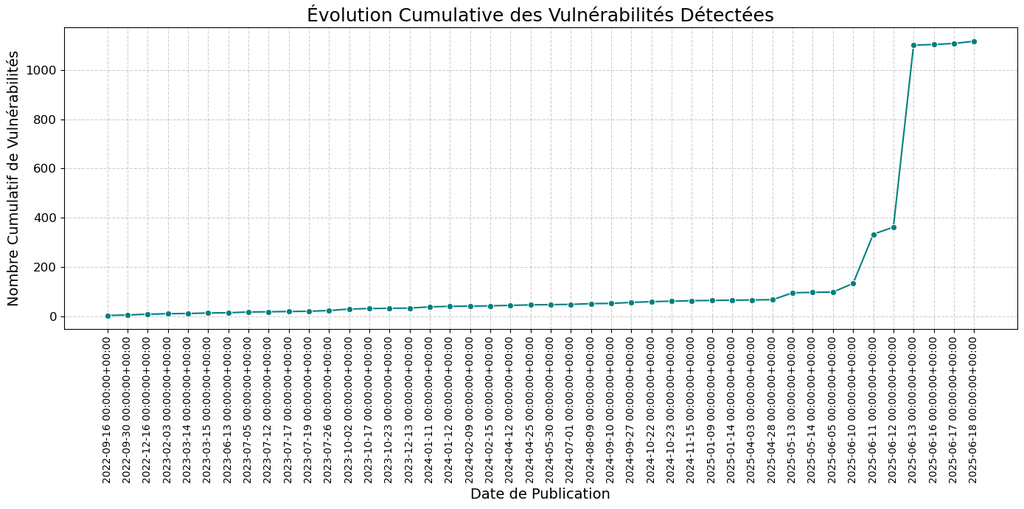

```python
import matplotlib.dates as mdates

# Sort by date
df_sorted_by_date = df_cve_unique.sort_values('Published')
df_sorted_by_date['Cumulative Vulnérabilités'] = range(1, len(df_sorted_by_date) + 1)

cumulative_df = df_sorted_by_date.groupby('Published').size().reset_index(name='Daily Vulnerabilities')
cumulative_df['Cumulative Vulnérabilités'] = cumulative_df['Daily Vulnerabilities'].cumsum()

plt.figure(figsize=(14, 7))

sns.lineplot(data=cumulative_df, x='Published', y='Cumulative Vulnérabilités',
             marker='o', linestyle='-', color='teal')

plt.title('Évolution Cumulative des Vulnérabilités Détectées', fontsize=18)
plt.xlabel('Date de Publication', fontsize=14)
plt.ylabel('Nombre Cumulatif de Vulnérabilités', fontsize=14)

# Y-axis ticks
plt.yticks(fontsize=12)
plt.xticks(rotation=90)

plt.grid(True, linestyle='--', alpha=0.6)

plt.tight_layout()
plt.show()
```

## Interprétation - Evolution Cumulative des Vulnérabilités Détectées

L'augmentation soudaine et spectaculaire du nombre de vulnérabilités en juin 2025 (autour des 5 et 18 juin) suggère fortement une importation massive de données ou une mise à jour majeure de la base de données plutôt qu'une découverte organique et progressive de vulnérabilités.

La section initiale à croissance lente pourrait représenter des vulnérabilités ajoutées au fur et à mesure, ou il s'agit d'une base de données qui a été alimentée progressivement avant une intégration plus large.

La date du 5 au 13 juin 2025 marque un point de bascule où le volume d'informations sur les vulnérabilités dans le système a été multiplié par un facteur très important (près de 10 fois).

# 9. Boxplot des scores CVSS par éditeurs

### Montrer la dispersion des scores CVSS pour les éditeurs les plus affectés

[figure not shown]

```python
top_n_vendors = df_produit_unique['vendor'].value_counts().head(5).index
df_top_vendors = df_produit_unique[df_produit_unique['vendor'].isin(top_n_vendors)]

plt.figure(figsize=(12, 8))
sns.boxplot(data=df_top_vendors, x='vendor', y='CVSS_score', hue='vendor', palette='pastel', legend=False)
plt.title('Distribution des Scores CVSS par Éditeur (Top 5)', fontsize=16)
plt.xlabel('Score CVSS', fontsize=12)
plt.ylabel('Éditeur/Vendor', fontsize=12)
plt.xticks(fontsize=12)
plt.yticks(fontsize=12)
plt.show()
```